# Series de tiempo

# El curso *Series Temporales* de Udemy

Estas notas se basan en el curso titulado *Series Temporales* que se encuentra disponible en la plataforma educativa [Udemy](https://www.udemy.com/course/series-temporales/) y que imparte [Elisa Cabana](https://aprendeconeli.com/) al lado de [Juan Gabriel Gomila](https://frogames.es/rutas-de-aprendizaje/).

Desde luego que las notas no pretenden ser un sustituto del gran curso diseñado por los antes mencionados, pero si pretende servir como guía de acompañamiento para quienes decidan tomar o el curso, o a manera de guía rápida para quienes solo quieren recordar algunos conceptos básicos.

Estas notas, evidentemente, están escritas en `R Markdown`.

# Introducción

Las series temporales o series de tiempo son una colección de datos numéricos que se encargan de describir el comportamiento de alguna variable cuya dependencia en el tiempo y el orden cronológico del mismo es crucial. Por ejemplo, si pensamos que en los precios de cierto producto, la dependencia del tiempo será de vital importancia para saber si en algún momento del año ese producto se encarece o no; los pronósticos meteorológicos también dependen de la cronología en la que se acumulan los datos pues podremos *predecir* si el día de mañana es más probable que llueva si sabemos que en los últimos 2 días se han mantenido las lluvias.

Como en el ejemplo meteorológico, no solo deseamos describir los datos que se presentan en orden cronológico, si no que tambien deseamos predecir, o dicho más apropiadamente, **pronosticar** el compartimiento de los datos en el futuro. Esta tarea esta a cargo de herramietas estadísticas y matemáticas para obtener el mejor de los resultados basado en las tendencias, patrones, estacionalidades y estabilidad de los datos.

## Notación matemática

Una colección de datos $X$ sobre un periodo de tiempo $T$ será representada como $(x_t)$ donde para cada observación en el tiempo $t$ se tiene el dato $x_t$. Se puede pensar a $T$ como una partición regular de todo el periodo de tiempo como sigue
$$T = \{t_1<t_2<\cdots<t_n\}.$$
De tal modo que la diferencia entre cada par consecutivo es constante, es decir $t_2 - t_1 = t_3 -t_2 = \cdots=t_n - t_{n-1}$.

Por supuesto que siempre será posible reemplazar la notación anterior, y a manera de estandarizar las observaciones, reemplazando $t_i = i$, pues solo nos interesa el orden cronóligico y siempre será posible reinterpretar de acuerdo a la necesidad del problema. De este modo $x_4$ representa la observación que se hace en el cuarto periodo de tiempo.

# Series de tiempo en `R`

## Ejemplo de carga de datos en R

```r
library(tidyverse)
```

Cargamos el siguiente archivo que se encuentra en formato `csv`. Y demos un vistazo a su contenido.

```r
datos <- read.csv("Files/Index2018.csv")

str(datos)
```

```
## 'data.frame':    6269 obs. of  5 variables:
##  $ ï..date: chr  "07/01/1994" "10/01/1994" "11/01/1994" "12/01/1994" ...
##  $ spx    : num  470 475 474 474 472 ...
##  $ dax    : num  2225 2225 2228 2182 2142 ...
##  $ ftse   : num  3446 3441 3414 3372 3360 ...
##  $ nikkei : num  18124 18443 18485 18794 18577 ...
```

```r
summary(datos)
```

```
##    ï..date               spx              dax             ftse
##  Length:6269        Min.   : 438.9   Min.   : 1912   Min.   :2877
##  Class :character   1st Qu.: 990.7   1st Qu.: 4069   1st Qu.:4486
##  Mode  :character   Median :1233.4   Median : 5773   Median :5662
##                     Mean   :1288.1   Mean   : 6080   Mean   :5423
##                     3rd Qu.:1460.0   3rd Qu.: 7443   3rd Qu.:6304
##                     Max.   :2872.9   Max.   :13560   Max.   :7779
##      nikkei
##  Min.   : 7055
##  1st Qu.:10709
##  Median :15028
##  Mean   :14597
##  3rd Qu.:17860
##  Max.   :24124
```

```r
head(datos)
```

```
##      ï..date    spx     dax    ftse   nikkei
## 1 07/01/1994 469.90 2224.95 3445.98 18124.01
## 2 10/01/1994 475.27 2225.00 3440.58 18443.44
## 3 11/01/1994 474.13 2228.10 3413.77 18485.25
## 4 12/01/1994 474.17 2182.06 3372.02 18793.88
## 5 13/01/1994 472.47 2142.37 3360.01 18577.26
## 6 14/01/1994 474.91 2151.05 3400.56 18973.70
```

Antes de modificar el problema más evidente (el nombre de la primer columna de `datos`: ï..date), notemos lo siguiente:

- La primer columna columna contiene fechas codificadas como una cadena de caracteres. Sin embargo, esas fechas parecen estar en orden cronológico ascendente (de la fecha más vieja a la más actual).
- El resto de las columnas contiene datos numéricos.
- En ninguna observación tenemos registros con `NA` (si los hubiera, la función `summary` lo hubiera contabilizado).

Ahora cambiemos solo el nombre de la primer columna de `datos` y codifiquemos las fechas en el formato correcto

```r
colnames(datos)[1] <- "dates"
datos$dates <- as.Date(datos$dates, format = "%d/%m/%Y")
str(datos)
```

```
## 'data.frame':    6269 obs. of  5 variables:
##  $ dates : Date, format: "1994-01-07" "1994-01-10" ...
##  $ spx   : num  470 475 474 474 472 ...
##  $ dax   : num  2225 2225 2228 2182 2142 ...
##  $ ftse  : num  3446 3441 3414 3372 3360 ...
##  $ nikkei: num  18124 18443 18485 18794 18577 ...
```

## Gráficas de las series de tiempo

Grafiquemos la **serie de tiempo** de la variable `spx`.

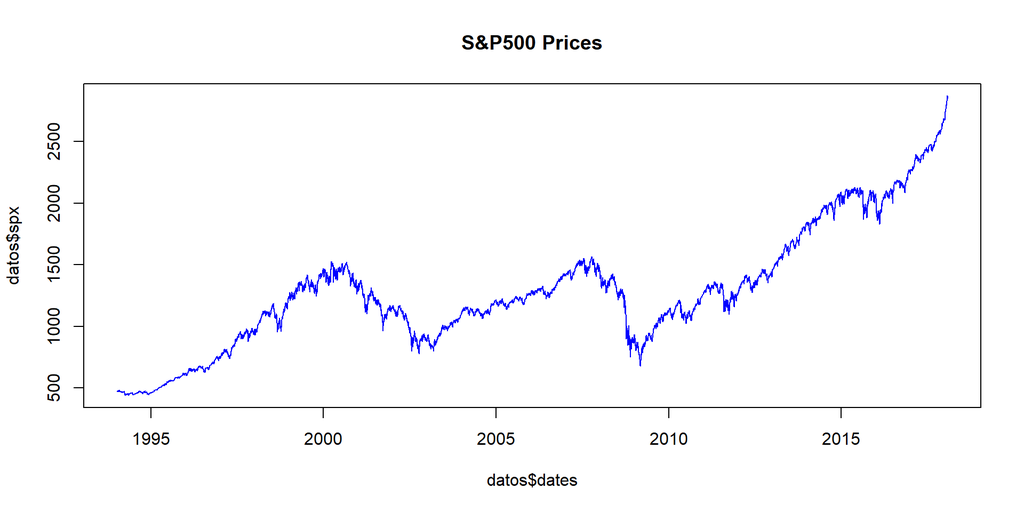

```r
plot(datos$dates, datos$spx, type = "l", col = "blue")
title("S&P500 Prices")
```

Podemos ver que alrededor del año 2000 tenemos valores que sugieren una pequeña burbuja o alza en los precios seguida de una caída un poco brusca. Lo mismo sucede alrededor del 2007.

Ahora veamos el gráfico para la variable `ftse` para comparar los patrones.

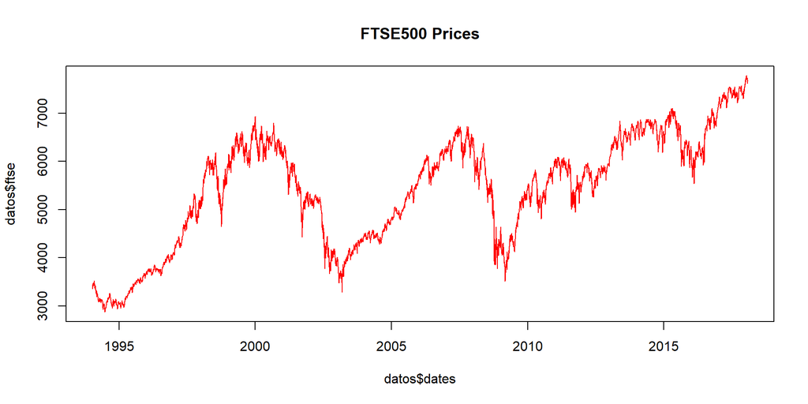

```r
plot(datos$dates, datos$ftse, type = "l", col = "red")
title("FTSE500 Prices")
```

Lo anterior parece indicar que se comparte le mismo patrón de las caídas y bajas en los precios de ambos productos. Por supuesto, lo anterior puede explicarse debido a la similitud entre los mercados bursátiles de EEUU (*S&P 500*) y los británicos (*FTSE 100*).

Pero veamos como se comportan al mismo tiempo en una gráfica.

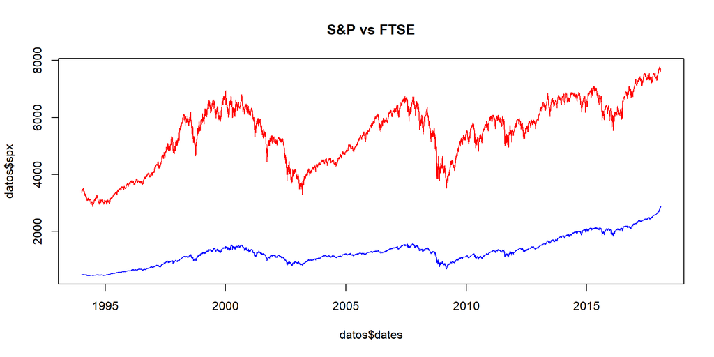

```r
min_y <- min(c(datos$spx, datos$ftse))
max_y <- max(c(datos$spx, datos$ftse))
plot(datos$dates, datos$spx, type = "l", col = "blue", ylim = c(min_y, max_y))
lines(datos$dates, datos$ftse, col = "red")
title("S&P vs FTSE")
```

Podemos notar que la serie de tiempo de **S&P** “parece verse más estable” que la de **FTSE**. Pero esto es engañoso, pues se debe a la magitud en la que cambian cada uno de los precios.

## Intensidad de los datos

Para identificar la probablidad de los datos o cuales son más probables de salir utilizamos la gráfica *Q-Q plot*, también conocida como gráfica cuartil-cuartil.

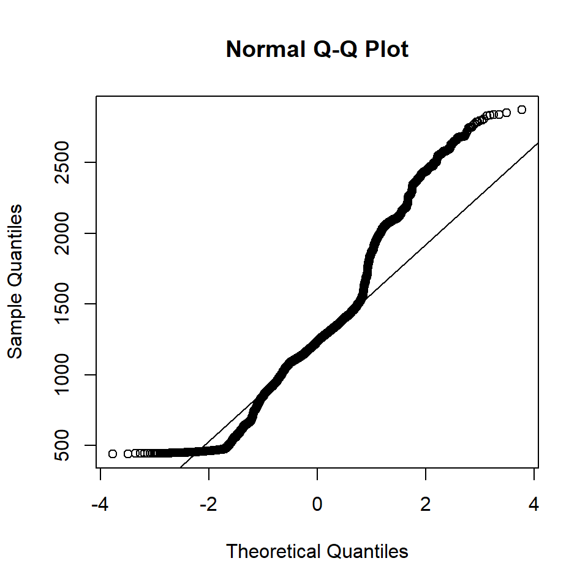

```r
qqnorm(datos$spx)
qqline(datos$spx)
```

## Frecuencia de los datos

Veamos las primeras fechas con las que graficamos los datos.

```r
datos$dates[1:20]
```

```
##  [1] "1994-01-07" "1994-01-10" "1994-01-11" "1994-01-12" "1994-01-13"
##  [6] "1994-01-14" "1994-01-17" "1994-01-18" "1994-01-19" "1994-01-20"
## [11] "1994-01-21" "1994-01-24" "1994-01-25" "1994-01-26" "1994-01-27"
## [16] "1994-01-28" "1994-01-31" "1994-02-01" "1994-02-02" "1994-02-03"
```

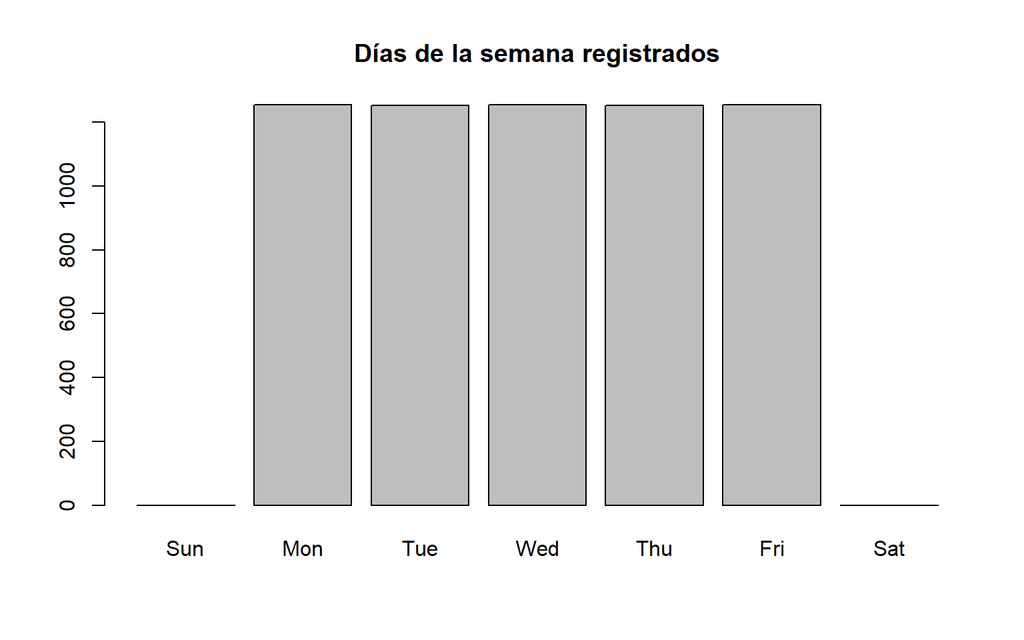

```r
week_days <- wday(datos$dates, label = T, abbr = T)
plot(week_days)
title("Días de la semana registrados")
```

```r
table(week_days)
```

```
## week_days
##  Sun  Mon  Tue  Wed  Thu  Fri  Sat
##    0 1255 1253 1254 1253 1254    0
```

La gráfica y tabla anterior nos muestra que todas las observaciones son registradas en los días de lunes a viernes o **business days**. Por lo tanto, si nuestro marco de referencia es solamente a través de los *business days*, entonces la frecuencia de los datos si es regular y podremos seguir con nuestro análisis.

No obstante, si lo que deseamos es tener observaciones de **todos los días** del año, entonces debemos crear esas observaciones.

```r
# Creamos una secuencia diaria de nuestras oberservaciones
dates_by_day <- data.frame(days = seq(min(datos$dates), max(datos$dates), by = "day"))

# Juntamos los días con los datos originales y los huecos se llenaran con NA's
datos_alldays <- dates_by_day %>%
  left_join(datos, by = c("days" = "dates"))
head(datos_alldays)
```

```
##         days    spx     dax    ftse   nikkei
## 1 1994-01-07 469.90 2224.95 3445.98 18124.01
## 2 1994-01-08     NA      NA      NA       NA
## 3 1994-01-09     NA      NA      NA       NA
## 4 1994-01-10 475.27 2225.00 3440.58 18443.44
## 5 1994-01-11 474.13 2228.10 3413.77 18485.25
## 6 1994-01-12 474.17 2182.06 3372.02 18793.88
```

Ahora tenemos observaciones pero nos enfrentamos a valores vacíos.

```r
summary(datos_alldays[-c(1)])
```

```
##       spx              dax             ftse          nikkei
##  Min.   : 438.9   Min.   : 1912   Min.   :2877   Min.   : 7055
##  1st Qu.: 990.7   1st Qu.: 4069   1st Qu.:4486   1st Qu.:10709
##  Median :1233.4   Median : 5773   Median :5662   Median :15028
##  Mean   :1288.1   Mean   : 6080   Mean   :5423   Mean   :14597
##  3rd Qu.:1460.0   3rd Qu.: 7443   3rd Qu.:6304   3rd Qu.:17860
##  Max.   :2872.9   Max.   :13560   Max.   :7779   Max.   :24124
##  NA's   :2520     NA's   :2520    NA's   :2520   NA's   :2520
```

## Valores Faltantes (`NA`)

Al modificar la lógica de nuestras observaciones ahora tenemos `NA` para algunos días. Para esto, será útil la librería `zoo`. Para ellos, debemos crear un objeto `ts` solamente con los datos de S&P.

Veamos que efectivamente ahora tenemos huecos en nuestra serie de tiempo (al menos en los primeros 20 días).

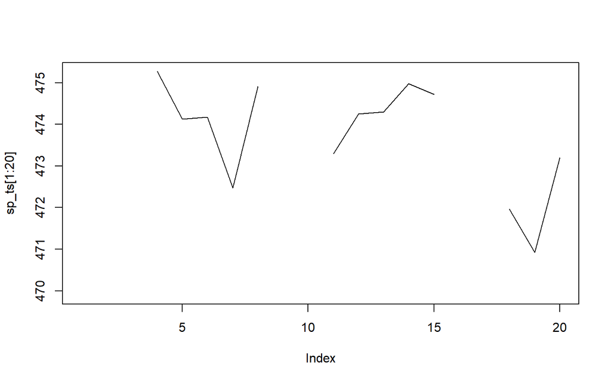

```r
library(zoo)
sp_ts <- ts(datos_alldays$spx)
plot(sp_ts[1:20], type = "l")
```

Hay distintas maneras de llenar esos huecos. Los más relevantes son:

- Asignar un valor fijo para todos.
- **LOCF** (Last Observation Carried Forward): Reemplazar con el dato inmediato anterior distinto de un `NA`.
- **NOCB** (Next Observation Carried Backward): Reemplazar con el dato inmediato siguiente distinto de un `NA`.
- Hacer interpolación para esos datos (mediante rectas o *splines*).

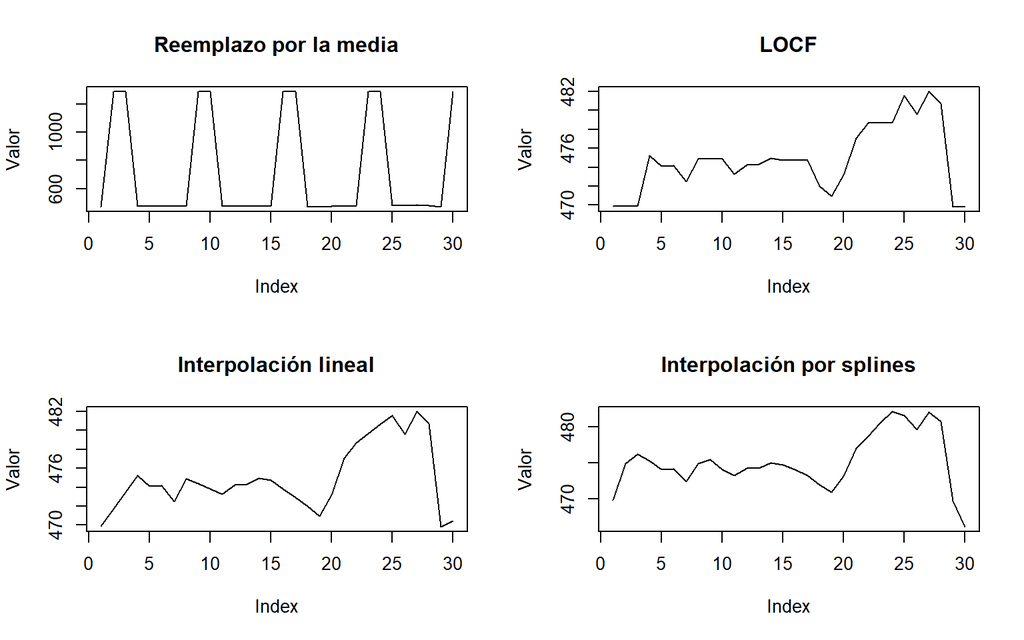

```r
# Todos los NA's son reemplazados por la media de todas las observaciones
sp_ts.mean <- na.aggregate(sp_ts)
# Valor inmediato anterior disinto a ese NA
sp_ts.locf <- na.locf(sp_ts)
# Interpolación lineal
sp_ts.linear <- na.approx(sp_ts)
# Interpolación de splines cúbicos
sp_ts.spline <- na.spline(sp_ts)
par(mfrow=c(2,2))
plot(sp_ts.mean[1:30], type = "l", ylab= "Valor")
title("Reemplazo por la media")
plot(sp_ts.locf[1:30], type = "l", ylab= "Valor")
title("LOCF")
plot(sp_ts.linear[1:30], type = "l", ylab= "Valor")
title("Interpolación lineal")
plot(sp_ts.spline[1:30], type = "l", ylab= "Valor")
title("Interpolación por splines")
```

## Conjunto de Entrenamiento y de Prueba

En cualquier otro método conocido de aprendizaje de máquina se toman observaciones aleatorias para generar los conjuntos de datos de entrenamiento y de prueba. Sin embargo, el orden cronológico en las series de tiempo es crucial y solamente podremos dividir en dos respetando el orden. Es decir, podemos tomar como nuestro conjunto de entrenamiento al 80% de las primeras observaciones y el resto como nuestro conjunto de prueba.

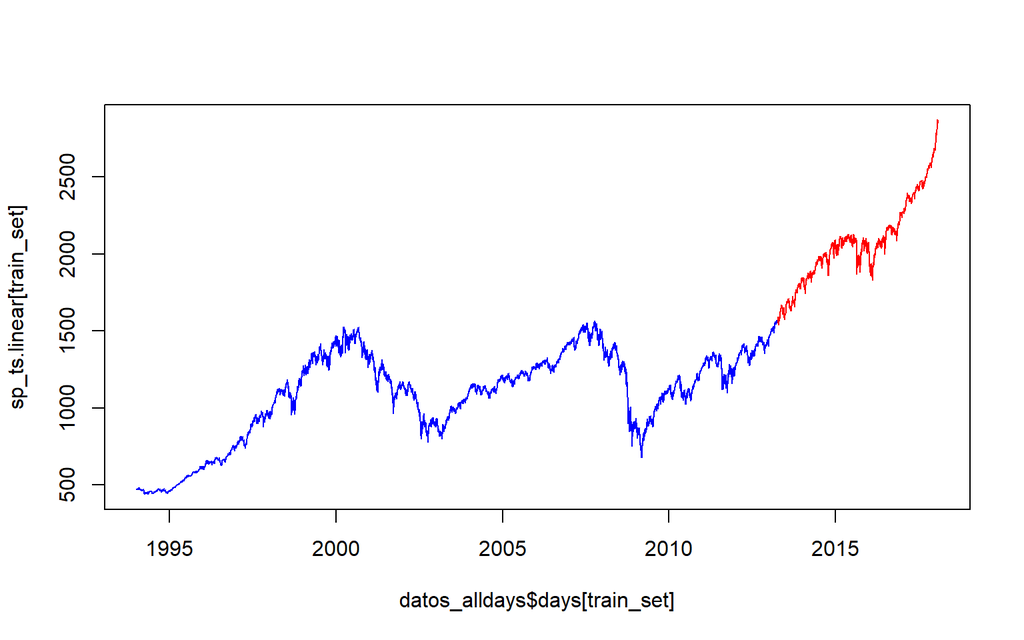

```r
datos_alldays$spx_fill <- sp_ts.linear
limite <- floor(length(sp_ts.linear)*0.8)
train_set <- c(1:limite)
test_set <- c((limite+1):length(sp_ts.linear))

par(mfrow=c(1,1))
plot(datos_alldays$days[train_set], sp_ts.linear[train_set], type="l",
     col = "blue", xlim = c(min(dates_by_day$days), max(dates_by_day$days)),
     ylim = c(min(sp_ts.linear), max(sp_ts.linear)))
lines(datos_alldays$days[test_set], sp_ts.linear[test_set], col="red")
```

En este caso, nuestros datos de entrenamiento son los marcados en azul y el conjunto de prueba es el marcado en rojo.

# Series de tiempo notables

## Ruido Blanco

Recordemos que la idea analizar series de tiempo es tratar de predecir o hacer pronósticos con base en datos del pasado. Existe la posibilidad de toparnos con una serie de tiempo conocida como **ruido blanco** que nos imposibilita cumplir con la condición de hacer predicciones del futuro.

Para considerar a una serie como ruido blanco, esta debe satisfacer 3 condiciones:

- Media constante
- Varianza constante
- No tener autocorrelaciones

Para medir la autocorrelación debemos calcular la correlación que hay entre un valor al tiempo $t$ y el valor inmediato anterior. Es decir,

$$\rho = \text{corr}(x_t, x_{t+1}).$$
Entonces, esperamos que la correlación sea una serie de valores que se comporta aleatoriamente.

A manera de comparar una serie de ruido blanco con una serie temporal que puede tener predicciones, mostramos una serie de tiempo (en azul) y una serie de ruido blanco en gris.

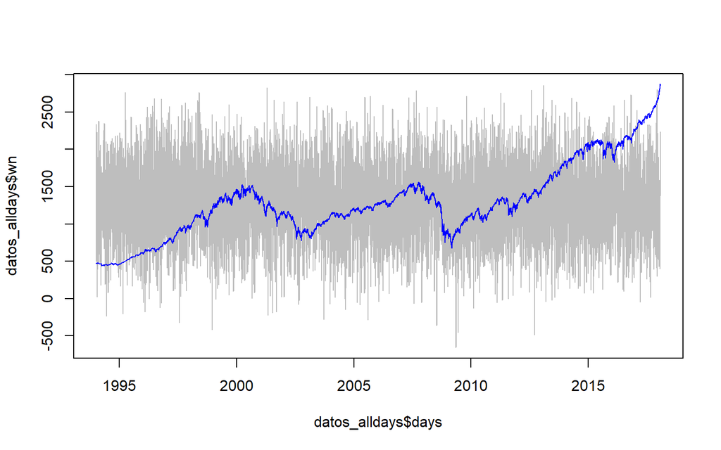

```r
wn <- rnorm(length(datos_alldays$spx_fill), mean = mean(datos_alldays$spx_fill), sd = sd(datos_alldays$spx_fill))
datos_alldays$wn <- wn
plot(datos_alldays$days, datos_alldays$wn, type = "l", col = "gray",
     ylim = c(min(datos_alldays$spx_fill, datos_alldays$wn),max(datos_alldays$spx_fill, datos_alldays$wn)))
lines(datos_alldays$days, datos_alldays$spx_fill, col = "blue")
```

## Caminatas Aleatorias

Será cuando los valores tienden a persistir en el tiempo y las diferencias entre ellos solo es ruido blanco. Por ejemplo, el proceso dado por $P_t = P_{t-1} + \varepsilon_t$ donde $\varepsilon \sim \mathcal{N}(\mu,\sigma^2)$ es un ejemplo de caminata aleatoria. Notemos que mientras más resultados queramos predecir será más difícil encontrar valores estables pues se acumulan los errores o el ruido blanco.

```r
rw <- read.csv("Files/RandWalk.csv")
str(rw)
```

```
## 'data.frame':    7029 obs. of  2 variables:
##  $ date : chr  "07/01/1994" "08/01/1994" "09/01/1994" "10/01/1994" ...
##  $ price: num  1122 1135 1110 1080 1082 ...
```

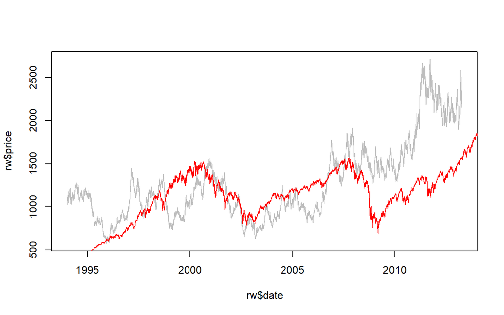

```r
rw$date <- as.Date(rw$date,"%d/%m/%Y")
plot(rw$date, rw$price, type = "l", col = "gray")
lines(datos_alldays$days,datos_alldays$spx_fill, col = "red")
```

```r
rw.ts <- ts(rw$price)
```

Podemos notar que las caminatas aleatorias se parecen más a una serie temporal usual.

En finanzas, se conoce como *eficiencia del mercado* al nivel de dificultad para pronosticar valores correctos. En general, si una serie temporal se asemeja a una caminata aleatoria, los precios no pueden predecirse con gran precisión. Por otro lado, si se pueden predecir con precisión habrá oportunidades de arbitraje. Es decri, los inversores pueden vender y comprar productos mientras se ajustan los precios y obtener ganancias de dichas operaciones.

A continuación mostramos como generar caminatas aleatorias:

```r
RW <- function(N, x0, mu, variance) {
  z<-cumsum(rnorm(n=N, mean=0,
                  sd=sqrt(variance)))
  t<-1:N
  x<-x0+t*mu+z
  return(x)
  }

P1<-RW(100,10,0,0.0004)
P2<-RW(100,10,0,0.0004)
plot(P1, main="Random Walk",
     xlab="t",ylab="Price", ylim=c(9.7,10.3),
     typ='l', col="red")

par(new=T)  # para hacer ambos dibujos en el mismo plot

plot(P2, main="Random Walk",
     xlab="t",ylab="Price", ylim=c(9.7,10.3),
     typ='l', col="blue")
```

[output not shown]

# Descomposiciones y Filtros

Diremos que una serie de tiempo presenta estacionalidad si es estable a lo largo del tiempo, es decir, cuando la **media** y la **varianza** son constantes en el tiempo, y además no presenta tendencia.

Entonces una serie no estacionaria será aquella cuya tendencia cambia en el tiempo. Por lo que no oscila alrededor de la media constante.

Una forma de verificar estacionalidad veremos que si al tomar dos secuencias de datos consecutivas de la misma longitud, tendrán covarianzas iguales, independientemente del punto inicial. Esta propiedad se conoce como *estacionariedad en forma débil* o *estacionariedad en covarianza*. La propiedad de de covarianza se escribe como
$$\text{cov}(x_n, x_{n+k}) = \text{cov}(x_m, x_{m+k}).$$

Cuando las muestras tienen las mismas distribuciones, entonces llamaremos a las series con *estacionariedad estricta*. Esto se define como, si $(x_t, x_{t+k})\sim\mathcal{F}(\theta)$ entonces $(x_{t+\tau}, x_{t+k+\tau})\sim\mathcal{F}(\theta)$.

## Prueba Dickey-Fuller (D-F)

Se basa en una prueba de hipótesis para determinar si una serie de tiempo presenta estacionariedad.

$$H_0: \text{La serie no es estacionaria}\\\text{vs}
\\H_a: \text{La serie es estacionaria}$$

O bien,

$$H_0: \varphi = 1\qquad\text{vs}
\qquad H_a: \varphi < 1$$

donde, $\varphi_k = \text{corr}(x_t, x_{t-k})$ donde $k$ es el tiempo o retraso en dos periodos. Entonces, tomamos $\varphi_1 = \varphi$, es decir, el coeficiente de autorrelación de un retraso. Para aplicar la prueba D-F en `R` deberemos cargar la libreria `tseries`

```r
library(tseries)
rw.test <- adf.test(rw.ts, alternative = "stationary")
wn.test <- adf.test(ts(wn), alternative = "stationary")
spx.test <- adf.test(sp_ts.linear, alternative = "stationary")
data.frame("timeserie" = c("Random Walk", "White Noise", "SPX"), "p-value" = c(rw.test$p.value, wn.test$p.value, spx.test$p.value))
```

```
##     timeserie   p.value
## 1 Random Walk 0.2037444
## 2 White Noise 0.0100000
## 3         SPX 0.9900000
```

De aquí obtenemos que solamente el Ruido Blanco presenta evidencia significativa para decir que la serie presenta estacionariedad. pues el valor $p$ es menor que $0.05$. Recordemos que la elección del valor crítico del valor $p$ es un estándar dentro de la inferencia estadísticas, pero este debe fijarse antes de comnezar a realizar los cálculos estad´siticos y no modificarlo una vez que se obtengan los resultados.

## Estacionalidad

Sugiere que algunas tendencias apareceran de forma cíclica. Tales como el clima o las temperaturas.

Esto se puede realizar al descomponer a la serie de tiempo en tres partes:

- Tendencia: Muestra el patrón consistente de los datos ($\mu_t$)
- Estacional: Patrones cíclicos ($S_t$)
- Residual: Mostrará la diferencia entre los valores reales y el modelo que se ajusta ($\varepsilon_t$)

### Descomposición aditiva

Supngamos que para cada observación en el timepo, se puede descomponer como sigue:

$$X_t = \mu_t + S_t + \varepsilon_t$$

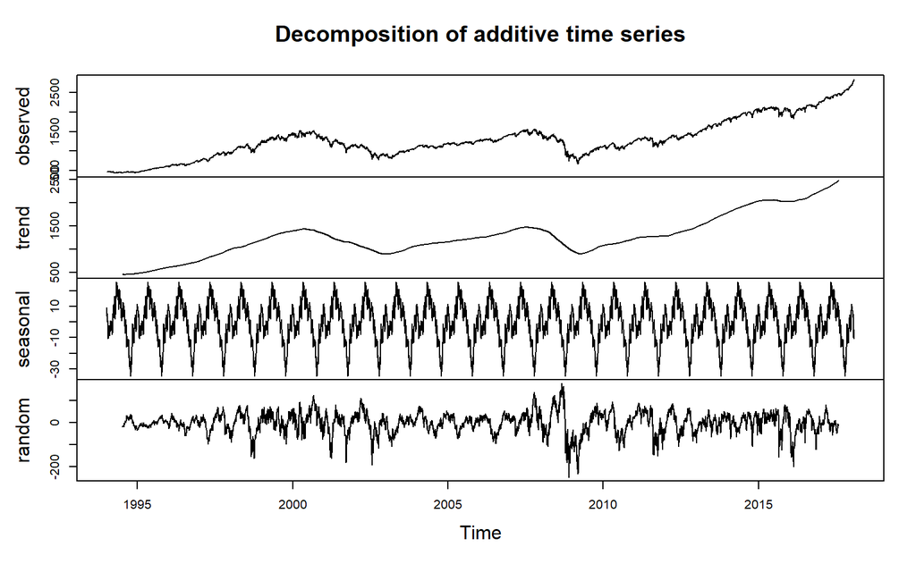

```r
# Since data starts daily in Jan 7th 1994 and ends Jan 28th 2018 then
# frequency = 365, start = c(1994,7) and end = c(2018, 29)
serie_spx <- ts(datos_alldays$spx_fill, frequency = 365, start = c(1994,7), end = c(2018, 29))

s_dec_add <- decompose(serie_spx, type = "add")

plot(s_dec_add)
```

### Descomposición multiplicativa

Supngamos que para cada observación en el timepo, se puede descomponer como sigue:

$$X_t = \mu_t S_t \varepsilon_t$$

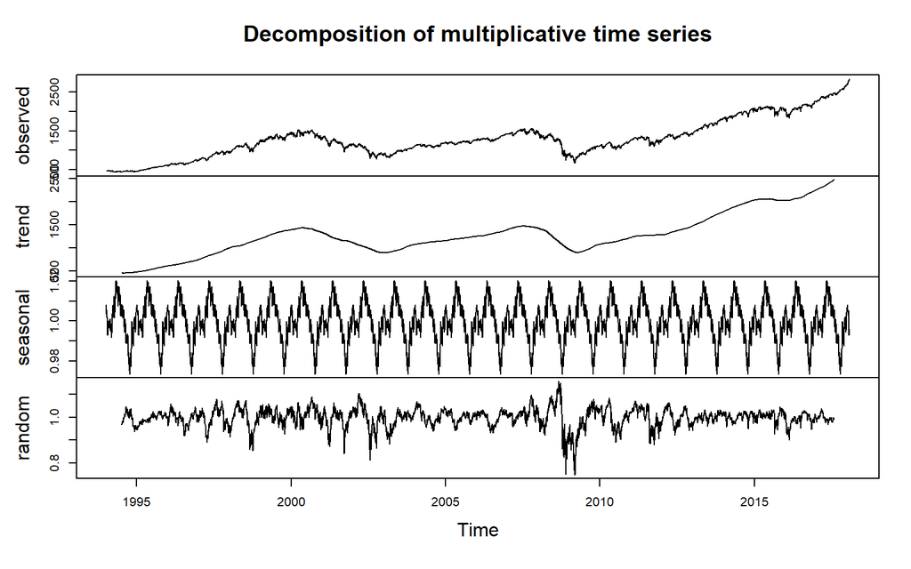

```r
s_dec_prod<- decompose(serie_spx, type = "mult")

plot(s_dec_prod)
```

Se pueden tener tendencia a la alza, a la baja u horizontales. Otro tipo de tendencia se puede encontrar mediante la estacionalidad pues es una tendencia repetitiva, por ejemplo, las búsquedas de la palabra **snowboarding** durante los últimos años.

## Filtro Hodrick Prescott

Es un método para descomponer una serie de tiempo en un componente tendencial y componente cíclico. De este modo, si $X_t$ es una nuestra serie de tiempo entonces,
$$X_t = \tau_t + c_t$$
. Luego, para un valor positivo $\lambda$ se calcula el componente tendencial mediante el siguiente problema de optimización

$$\min \sum_{t=1}^T(x_t-\tau_t)^2 + \lambda\sum_{t=2}^{T-1}\left[(\tau_{t+1}-\tau_t)-(\tau_t-\tau_{t-1})\right]^2$$

```r
macrodata <- read.csv("Files/macrodata.csv")
macrodata$X <- as.Date(macrodata$X, "%m/%d/%Y")
colnames(macrodata)[1] <- "dates"
head(macrodata)
```

```
##        dates year quarter  realgdp realcons realinv realgovt realdpi   cpi
## 1 1959-03-31 1959       1 2710.349   1707.4 286.898  470.045  1886.9 28.98
## 2 1959-06-30 1959       2 2778.801   1733.7 310.859  481.301  1919.7 29.15
## 3 1959-09-30 1959       3 2775.488   1751.8 289.226  491.260  1916.4 29.35
## 4 1959-12-31 1959       4 2785.204   1753.7 299.356  484.052  1931.3 29.37
## 5 1960-03-31 1960       1 2847.699   1770.5 331.722  462.199  1955.5 29.54
## 6 1960-06-30 1960       2 2834.390   1792.9 298.152  460.400  1966.1 29.55
##      m1 tbilrate unemp     pop infl realint
## 1 139.7     2.82   5.8 177.146 0.00    0.00
## 2 141.7     3.08   5.1 177.830 2.34    0.74
## 3 140.5     3.82   5.3 178.657 2.74    1.09
## 4 140.0     4.33   5.6 179.386 0.27    4.06
## 5 139.6     3.50   5.2 180.007 2.31    1.19
## 6 140.2     2.68   5.2 180.671 0.14    2.55
```

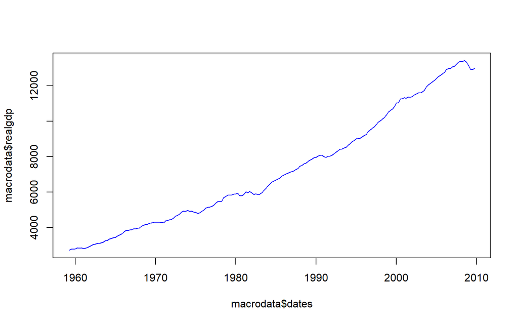

```r
plot(macrodata$dates, macrodata$realgdp, type = "l", col = "blue")
```

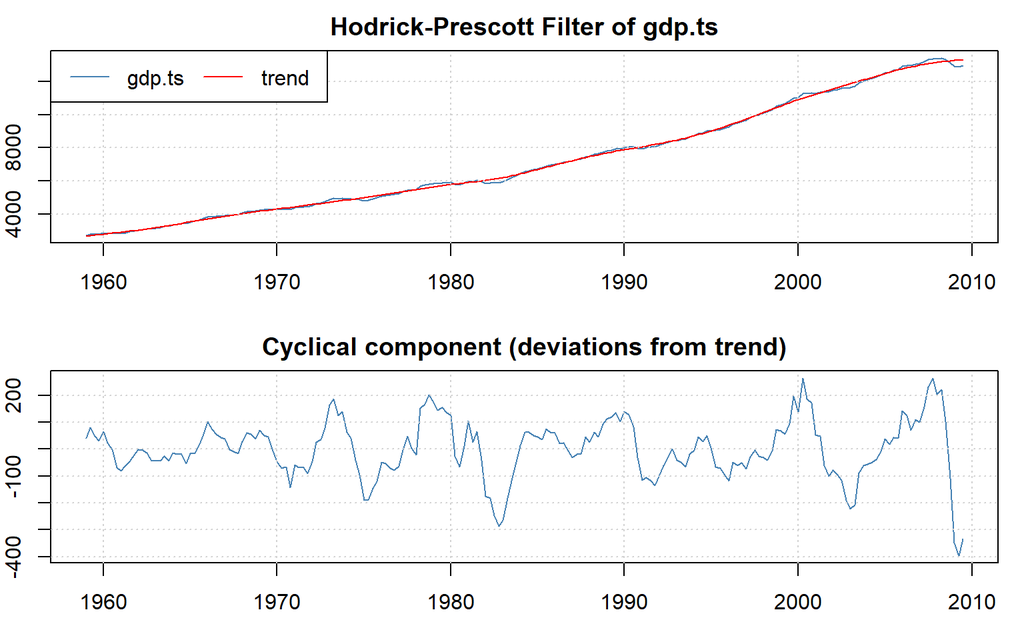

```r
gdp.ts <- ts(macrodata$realgdp, frequency = 4, start = c(1959,1))

# Como los datos son trimestrales entonces lambda = 1600
hp_gdp.ts <- mFilter::hpfilter(gdp.ts, freq = 1600)

plot(hp_gdp.ts)
```

```r
# plot(gdp.ts, col = "blue")
# lines(hp_gdp.ts$trend, col = "red")
# legend("topleft", legend = c("GDP", "Trend"),
#        col = c("blue", "red"), lty = 1)
```

## Ejemplo: Pasajeros de Avión

A continuación se carga el conjunto de datos que contiene la cantidad de pasajeros que vuela por mes desde Enero 1949 a Diciembre 1960.

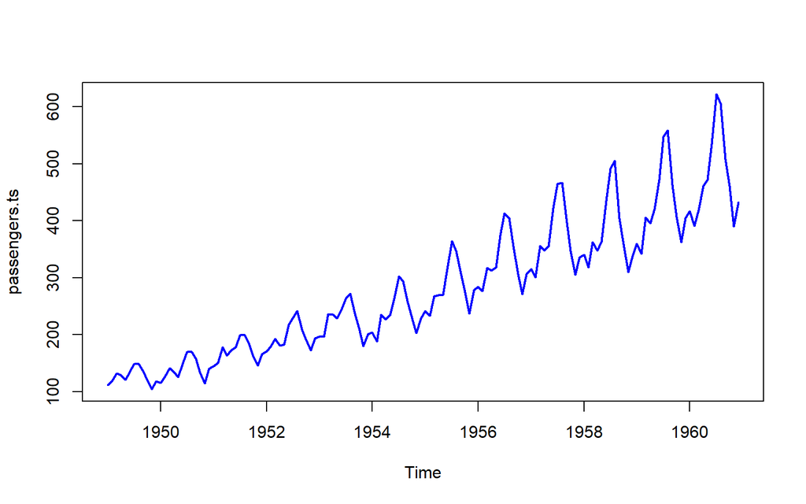

```r
airline <- read.csv("Files/airline_passengers.csv", col.names = c("month", "passengers"))
airline$month <- as.Date(airline$month, "%Y-%m")
passengers.ts <-ts(airline$passengers, frequency = 12, start = c(1949,1))
plot(passengers.ts, lwd = 2, col = "blue")
```

A simple vista podemos observar dos cosas: primero, parece que hay una tendencia exponencial porque es un poco más alta que la lineal; segundo, los datos parecen mostrar estacionalidad. Para ello, descompondremos los datos por estacionalidad aditiva.

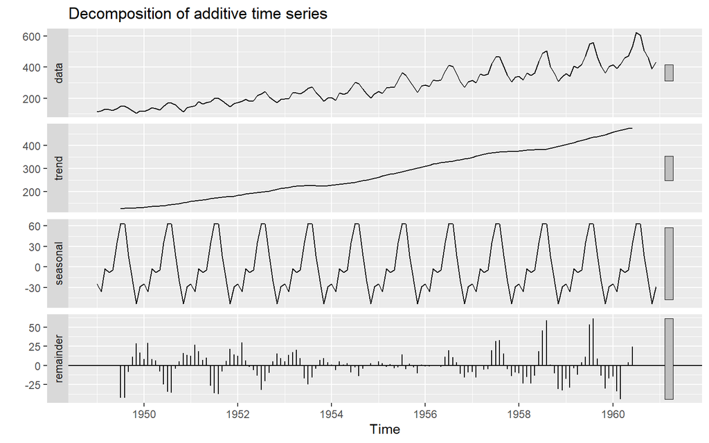

```r
dec_adit.passengers <- decompose(passengers.ts)
autoplot(dec_adit.passengers)
```

Por lo anterior, es claro que muestra estacionalidad anual y que efectivamente hay una tendencia a la alta. Para demostrar que la tendencia es exponencial deberá aislarse y analizarse por separado. Además, vemos que de acuerdo a nuestro modelo aditivo hay mucho ruido al principio y final de los datos que se visualiza en componente residual.

Ahora veamos la diferencia con la descomposición multiplicativa.

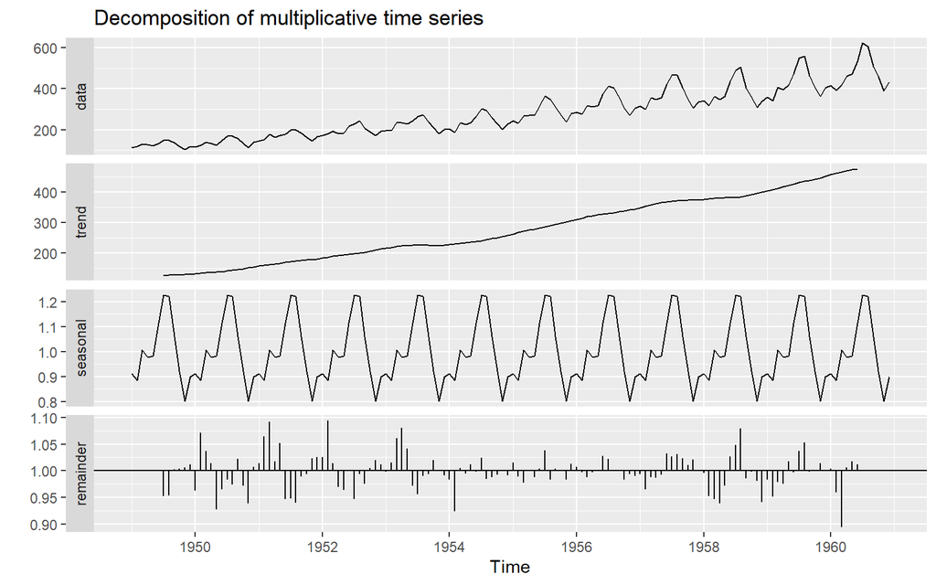

```r
dec_mult.passengers <- decompose(passengers.ts, type = "multiplicative")
autoplot(dec_mult.passengers)
```

La tendencia a la alza es claramente la misma en esta situación. Ahora, comparemos ambas tendencias con el gráfico original.

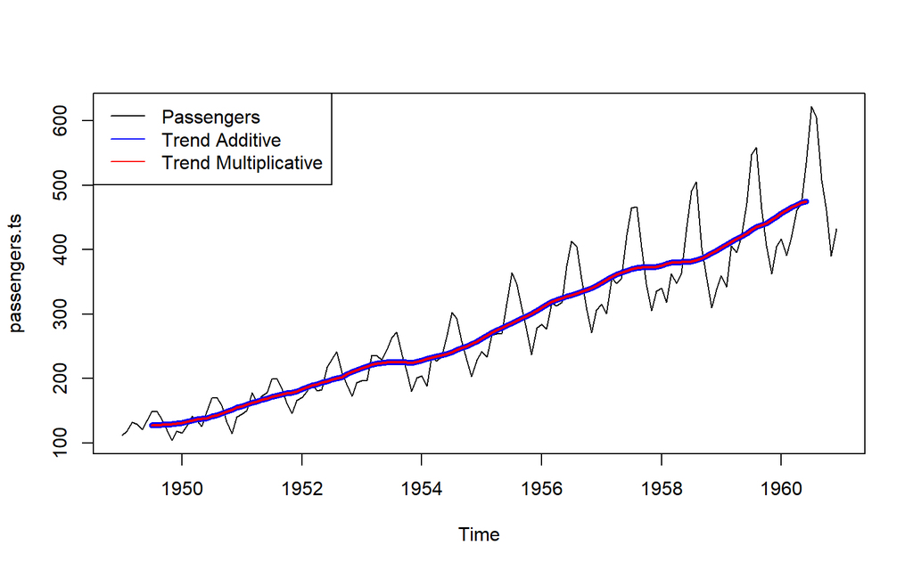

```r
trend_add <- dec_adit.passengers$trend
trend_mult <- dec_mult.passengers$trend
plot(passengers.ts, ylim = c(min(passengers.ts, trend_add, trend_mult, na.rm = T),
                             max(passengers.ts, trend_add, trend_mult, na.rm = T)))
lines(trend_add, col = "blue", lwd=5)
lines(trend_mult, col = "red", lwd=2)
legend("topleft", legend = c("Passengers", "Trend Additive", "Trend Multiplicative"),
        col = c("black", "blue", "red"), lty = 1)
```

## Autocorrelación

La correlación entre dos series temporales cambian sus valores. Para calcular la autocorrelación tomaremos una secuencia con retraso de $k$ periodos y la actual. Para ello introducimos la **función de autocorrelación**.

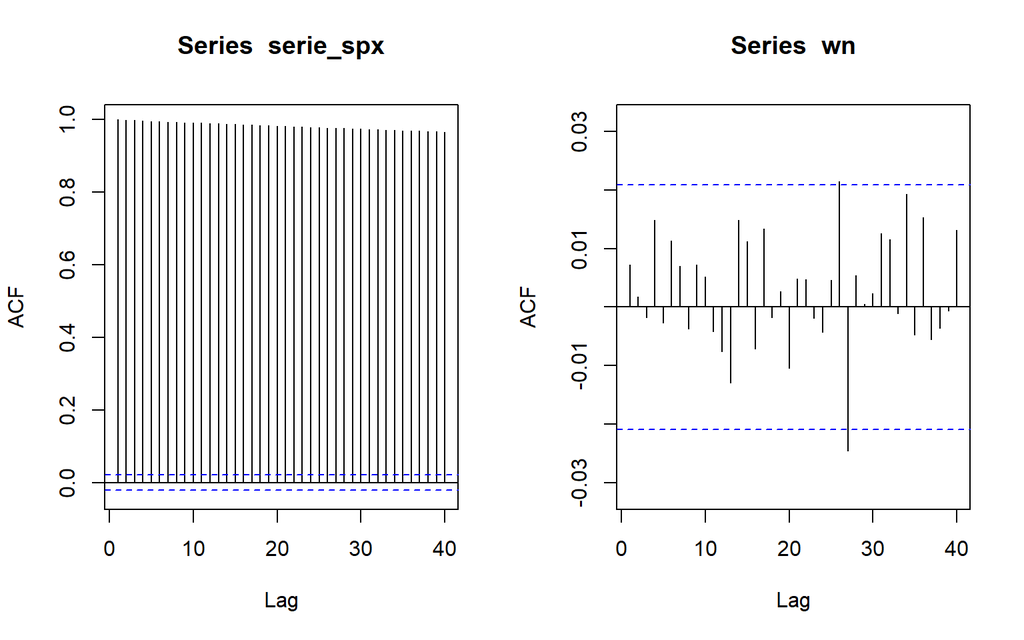

```r
library(forecast)
par(mfrow=c(1,2))
Acf(serie_spx, lag.max = 40)
Acf(wn, lag.max = 40)
```

Vemos que la grpafica de laizquierda gráfica la correlación de los precios SPX y que la derecha muestra la autocorrelación de solamente el ruido blanco. Esto nos da una buena idea para diferenciar una serie de tiempo útil que solamente ruido blanco.

### Autocorrelación Parcial

Si medimos la autocorrelación con $k$ retrasos del periodo actual entonces estaremos midiendo de forma directa los efectos de los periodos $k+1$, $k+2$, etc hasta llegar al actual. Del mismo modo, así como los periodos anteriores afectan al actual los previos a cualquiera de los periodos anteriores se afectan entre sí. Por ejemplo, considere que se calcula el coeficiente de autocorrelación del periodo actual $4$ con $3$ retrasos captura de forma **directa**, es decir los datos del periodo $1,2,3$ contribuyen a ese cálculo. Y, por otro lado, para el periodo $3$ tenemos que los periodos $1,2$ los afectan y para el periodo $2$ lo afecta el $1$, estas contribuciones afectan de forma **inderecta** al periodo $4$.

Entonces, para cada $k$ se define la autocorrelación parcial con $k$ retrasos como
$$\alpha(1) = \text{corr}(x_{t+1},x_t)\\
\alpha(k) = \text{corr}(x_{t+k} - P_{t,k}(x_{t+k}), x_{t} - P_{t,k}(x_{t}))$$

donde $P_{t,k}(x_{t})$ es la proyección de $x$ en el espacio abarcado por $x_{t+1}, \ldots, x_{t+k-1}$.

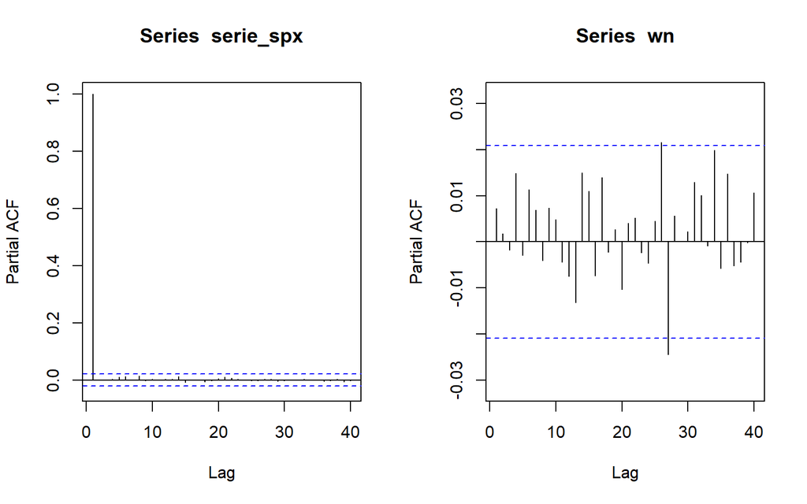

```r
par(mfrow=c(1,2))
Acf(serie_spx, lag.max = 40, type = "partial")
Acf(wn, lag.max = 40, type = "partial")
```

Notemos que para el gráfico de la izquierda ha cambiado significativamente su forma a los de la versión de autocorrelación. Es decir, nos dice que el efecto de los datos son directamente al precio de hoy. Por otro lado, si se encuentran dentro de la banda de confianza podemos deducir que no son significativamente distintos de cero, por lo que no son realmente importantes.

## Ejemplo: Temperaturas